# Descriptive Statistics with R

Bernard Ade

The goal of Descriptive Statistics is to summarize and describe a dataset. In this post, I will demonstrate how to use R to perform Descriptive Statistics on a small Dataset. My aim is to keep things simple and focus on illustrating R functions and packages such as dplyr and ggplot.

Lets explore the mpg dataset to gain some insight.

### Dataset

The data that we will use for this excercise is called mpg which comes installed with R. We can learn some basic characteristics by running ?mpg

```r
?mpg
```

| mpg {ggplot2} | R Documentation |
| --- | --- |

Fuel economy data from 1999 and 2008 for 38 popular models of car

Description

This dataset contains a subset of the fuel economy data that the EPA makes available on http://fueleconomy.gov. It contains only models which had a new release every year between 1999 and 2008 - this was used as a proxy for the popularity of the car.

Usage

```
mpg
```

Format

A data frame with 234 rows and 11 variables

- manufacturer.

- model.

- displ. engine displacement, in litres

- year.

- cyl. number of cylinders

- trans. type of transmission

- drv. f = front-wheel drive, r = rear wheel drive, 4 = 4wd

- cty. city miles per gallon

- hwy. highway miles per gallon

- fl.

- class.

[Package *ggplot2* version 2.1.0 ]

### Load Packages

```r
library(dplyr) # dplyr for data manipulation
library(ggplot2) #ggplot for data data visualization
options(warn = -1) #option to discard warning notifications
options(repr.plot.width=4, repr.plot.height=3) #option to size ggplot outputs
```

```r
#lets examine a few of the top rows of the dataset
head(mpg)
```

|  | manufacturer | model | displ | year | cyl | trans | drv | cty | hwy | fl | class |
| --- | --- | --- | --- | --- | --- | --- | --- | --- | --- | --- | --- |
| 1 | audi | a4 | 1.8 | 1999 | 4 | auto(l5) | f | 18 | 29 | p | compact |
| 2 | audi | a4 | 1.8 | 1999 | 4 | manual(m5) | f | 21 | 29 | p | compact |
| 3 | audi | a4 | 2 | 2008 | 4 | manual(m6) | f | 20 | 31 | p | compact |
| 4 | audi | a4 | 2 | 2008 | 4 | auto(av) | f | 21 | 30 | p | compact |
| 5 | audi | a4 | 2.8 | 1999 | 6 | auto(l5) | f | 16 | 26 | p | compact |
| 6 | audi | a4 | 2.8 | 1999 | 6 | manual(m5) | f | 18 | 26 | p | compact |

## Central Tendency

During the process of understanding data, one of the important goals is to obtain a figure that describes the center of a set of values. Lets describe some common descriptive statistical approaches for summarizing the central tendency using mode, median, mean, range and quartiles.

### Histogram

Before we dive into obtaining the summaries for various variables within our dataset, lets visualize the distribution of values within each variable to understand the data visually.

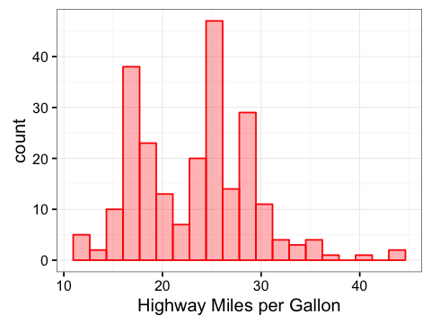

```r
ggplot(mpg, aes(hwy)) +
    geom_histogram(col="red", fill="red", alpha=0.3, bins = 20) +
    xlab("Highway Miles per Gallon") +
    theme_bw()
```

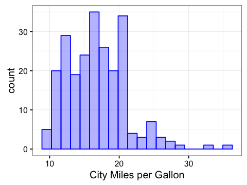

```r
ggplot(mpg, aes(cty)) +
    geom_histogram(col="blue", fill="blue", alpha=0.3, bins = 20) +
    xlab("City Miles per Gallon") +
    theme_bw()
```

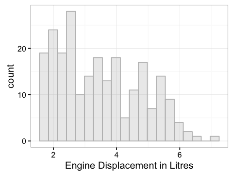

```r
ggplot(mpg, aes(displ)) +
    geom_histogram(col="gray", fill="gray", alpha=0.3, bins = 20) +
    xlab("Engine Displacement in Litres") +
    theme_bw()
```

### Mode

The mode is the most common value in a set. Using the table function in R we can easily discover the mode and plot the results for an eyeball.

```r
# we can obtain the mode by running the table() function
mode = table(mpg$displ)
mode
```

```
1.6 1.8 1.9   2 2.2 2.4 2.5 2.7 2.8   3 3.1 3.3 3.4 3.5 3.6 3.7 3.8 3.9   4 4.2
  5  14   3  21   6  13  20   8  10   8   6   9   4   5   2   3   8   3  15   4
4.4 4.6 4.7   5 5.2 5.3 5.4 5.6 5.7 5.9   6 6.1 6.2 6.5   7
  1  11  17   2   5   6   8   1   8   2   1   1   2   1   1
```

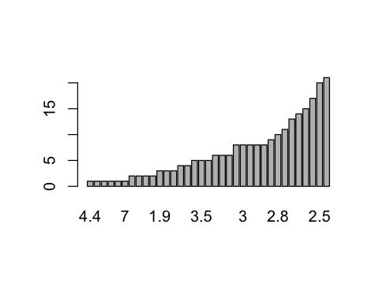

```r
mode = sort(mode)
barplot(mode)
```

### Mean

The mean also commonly referred to as average summarizes the central tenedency of a set.

```r
## we can obtain the mean by running the mean() function
mean(mpg$hwy)
```

23.4401709401709

### Median

The median is the middle value of a set after it has been sorted from high to low.

```r
#we can obtain the median by running the median() function
median(mpg$cty)
```

17

### Range

The range retuns the minimum and maximum value in a set. An alternative way to obtains these values is using the max and min function.

```r
# we can obtain the range by running the range() function
range(mpg$hwy)
```

1. 12

2. 44

```r
min(mpg$hwy)
```

12

```r
max(mpg$hwy)
```

44

### Quartile & Boxpot

Quartiles are the values that divides a set into quarters. An useful alterntive is to plot a boxplot for visuallizing quartiles and also detecting outliers.

```r
# we can obtain quartile by running the quantile() function
quantile(mpg$cty)
```

**0%**

9

**25%**

14

**50%**

17

**75%**

19

**100%**

35

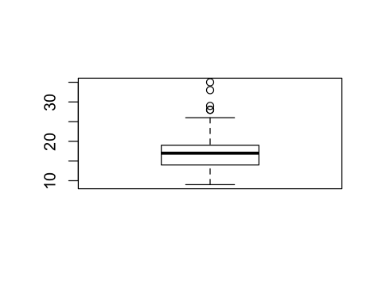

```r
boxplot(mpg$cty)
```

### Variance

The variance describes the spread of the data and measures how much a variables differs from the mean.

```r
var(mpg$hwy)
```

35.4577785114266

### Correlation

Correlation is useful for evaluating the relationship between two or more variables. Suppose we wanted to evaluate the relationship btw engine displacement and city miles per gallon. The cor function in R returns a value that describes the relationship between the engine displacement and the city miles per gallon. The negative correlation suggests that the bigger the engine diplacement the less fuel efficient the vehicle.

```r
cor(mpg$displ, mpg$cty)
```

-0.798523968934855

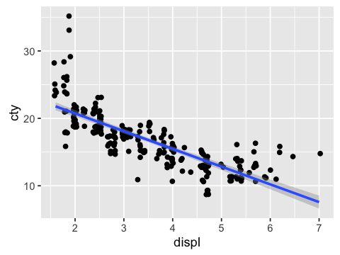

```r
ggplot(mpg, aes(x = displ, y = cty)) + geom_jitter() + geom_smooth(method=lm)
```

### Summary

Up untill this point we have gathered information about the dataset in separate parts. Its possible to do all of this at once using the summary function.

```r
summary(mpg)
```

```
 manufacturer          model               displ            year
 Length:234         Length:234         Min.   :1.600   Min.   :1999
 Class :character   Class :character   1st Qu.:2.400   1st Qu.:1999
 Mode  :character   Mode  :character   Median :3.300   Median :2004
                                       Mean   :3.472   Mean   :2004
                                       3rd Qu.:4.600   3rd Qu.:2008
                                       Max.   :7.000   Max.   :2008
      cyl           trans               drv                 cty
 Min.   :4.000   Length:234         Length:234         Min.   : 9.00
 1st Qu.:4.000   Class :character   Class :character   1st Qu.:14.00
 Median :6.000   Mode  :character   Mode  :character   Median :17.00
 Mean   :5.889                                         Mean   :16.86
 3rd Qu.:8.000                                         3rd Qu.:19.00
 Max.   :8.000                                         Max.   :35.00
      hwy             fl               class
 Min.   :12.00   Length:234         Length:234
 1st Qu.:18.00   Class :character   Class :character
 Median :24.00   Mode  :character   Mode  :character
 Mean   :23.44
 3rd Qu.:27.00
 Max.   :44.00
```